# EFA

Matt Dunham

3/1/2022

```
## ###############################################################################
```

[output not shown]

```
## ###############################################################################
```

```
## x ggplot2::%+%()      masks psych::%+%()
```

# Factor Analysis

For Factor Analysis, we first need to determine the appropriate number of factor to use. In order to accomplish this, let us perform Parallel Analysis.

## Parallel Analysis

```
##    Min. 1st Qu.  Median    Mean 3rd Qu.    Max.    NA's
##   16.00   18.00   19.00   20.47   21.00   59.00      40
```

```
##
##   16   17   18 18.9   19   20   21   22   23   24   25   26   27   28   29   30
##    1    4  667    1  593  524  293  141   52   33   25   26   15   21   19   12
##   31   32   33   34   35   36   37   38   39   40   41   42   43   44   46   48
##   15    5   10    4    7    4    1    4    2    3    3    7    1    3    1    1
##   49   50   56   57   59
##    1    1    2    2    2
```

```
##
## I prefer to self-identify:                        Man
##                0.013806706                0.351873767
##      Prefer not to answer.                      Woman
##                0.009861933                0.614595661
```

```
##
## Fifth or more years in college          Freshman (First Year)
##                    0.027218935                    0.313609467
##               Graduate student            High school student
##                    0.022485207                    0.009861933
##            Junior (Third Year)                         Other:
##                    0.226824458                    0.011834320
##   Part-time student in college           Senior (Fourth Year)
##                    0.014990138                    0.089546351
##        Sophomore (Second Year)
##                    0.273372781
```

```
##
##                   No Prefer not to answer                  Yes
##           0.64378698           0.01420118           0.32781065
```

```
## [1] -25
```

```
## [1] 2509
```

```
##
##                   No Prefer not to answer                  Yes
##                 1632                   36                  831
```

## Scree Plots

Scree plot generation can help us visualize our eigen values and determine the number of factors we have in our data. When generating these scree plots, contrary to the eigenvalue generation, we will be using the raw data and not a numeric matrix.

### PA

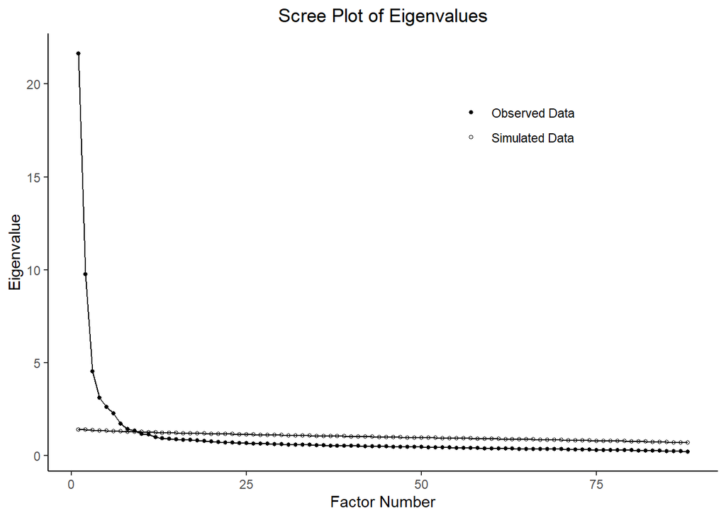

From this scree plot, we are seeing that we should extract 9 factors from our data. We will keep this in mind when moving to EFA.

We will now load our variables onto the amount of factors we obtained from Parallel Analysis.

## Skew and Kurtosis

Before we go ahead with EFA, we will check skew and kurtosis to see if we are horribly violating our normality assumptions. For similar preseasons why we visualized our data so indepthly, the normality violations of our data can determine possible limitations with EFA arguments.

Violations follow these stipulations:

- Skew < 3
- Kurtosis < 10

```
## [1] 1.215617
```

```
## [1] 1.538481
```

# Exploratory Factor Analysis

There are a few functions you can use for EFA. We considered both the fa and factanal functions, but decided to go with the fa function in the end. The factanal function assumes normality (which we could go ahead with since skew and kurtosis are fine), but also limits the arguments we can use in the data. The fa function allows for a more specific EFA argumentation.

Within the fa function, we are performing a promax rotation with a factoring method doing the principal factor solution. Along with this, we are using a polychoric correlation because we have data from a Likert scale, making our data ordinal and not continuous. This requires a polychoric correlation.

Using the fa function, we looked at two possible outcomes, one with a correction = 0 and one with a correction = 0.5. This correction determines how we should treat empty cells, but in the end did not change our loadings much at all. We went ahead with a correction = 0.

These arguments and function selection are consistent across both the groups.

## Sorting Method

We also will be printing out two versions of the loadings for each group: one where the variables are ordered (designed to show how well constructs are holding up), and another where the loadings are ordered by magnitude and factor (where we can see what the new constructs are looking like). Visualizing these loadings in these two different ways can help us when it comes to interpreting our EFA results and making decisions about question wording and new hypothesized constructs.

### Factor Analysis

**8 Factor Model**

```
##
## Loadings:
##               PA1    PA2    PA4    PA3    PA6    PA5    PA7    PA8
## Attain_1                                   0.567
## Attain_10                                  0.527
## Attain_11      0.543
## Attain_12                                  0.524
## Attain_13                                  0.550
## Attain_2
## Attain_3
## Attain_4             -0.676
## Attain_5                                   0.612
## Attain_6                                   0.520
## Attain_7       0.441                       0.435
## Attain_8
## Attain_9       0.751
## CostX_1                                           0.647
## CostX_2              -0.546
## CostX_3        0.795
## CostX_4        0.743
## CostX_5        0.488
## CostX_6        0.768
## CostX_7              -0.588
## CostX_8        0.820
## CostX_9        0.774
## CostX_10                                          0.637
## CostX_11                                          0.543
## CostX_12       0.704
## CostX_13       0.650
## DifficultyX_1         0.870
## DifficultyX_2         0.721
## DifficultyX_3         0.983
## DifficultyX_4         0.796
## DifficultyX_5
## DifficultyX_6         0.819
## DifficultyX_7         0.801
## DifficultyX_8         0.869
## DifficultyX_9         0.997
## GoalX_1                      0.730
## GoalX_2                      0.724
```

[output cut: 41 more lines]

```
## AcadSCX_5                           0.687
## AcadSCX_6                                                       0.407
## AcadSCX_7                           0.637
## AcadSCX_8                           0.636
## AcadSCX_9                                                       0.810
## AcadSCX_10                          0.437
## AcadSCX_11                          0.473
## AcadSCX_12                          0.557
## AcadSCX_13                                                      0.808
## AcadSCX_14                                                      0.465
##
##                   PA1   PA2   PA4   PA3   PA6   PA5   PA7   PA8
## SS loadings    16.249 9.016 4.723 4.561 3.484 2.787 2.512 1.928
## Proportion Var  0.185 0.102 0.054 0.052 0.040 0.032 0.029 0.022
## Cumulative Var  0.185 0.287 0.341 0.393 0.432 0.464 0.492 0.514
```

```
##
## Loadings:
##               PA1    PA2    PA4    PA3    PA6    PA5    PA7    PA8
## IntEnj_7       0.940
## IntEnj_2       0.890
## IntEnj_8       0.860
## IntEnj_4       0.841
## CostX_8        0.820
## CostX_3        0.795
## CostX_9        0.774
## CostX_6        0.768
## Utility_7      0.751
## Attain_9       0.751
## CostX_4        0.743
## Utility_8      0.740
## IntEnj_5       0.732
## CostX_12       0.704
## Utility_10     0.670
## CostX_13       0.650
## IntEnj_3       0.622
## Utility_9      0.618
## IntEnj_9       0.608
## Expectancy_6   0.580
## Attain_11      0.543
## Utility_11     0.527
## Expectancy_2   0.517
## CostX_5        0.488
## IntEnj_6       0.471
## Expectancy_5   0.450
## Attain_7       0.441                       0.435
## GoalX_7        0.440
## Utility_4      0.425                                     0.416
## Expectancy_1   0.423
## GoalX_4
## Expectancy_3
## DifficultyX_9         0.997
## DifficultyX_3         0.983
## DifficultyX_1         0.870
## DifficultyX_8         0.869
## DifficultyX_6         0.819
```

[output cut: 41 more lines]

```
## CostX_11                                          0.543
## Utility_6                                                0.636
## Utility_2                                                0.588
## Utility_3      0.462                                     0.569
## Utility_5      0.432                                     0.569
## Utility_1                                                0.522
## AcadSCX_9                                                       0.810
## AcadSCX_13                                                      0.808
## AcadSCX_14                                                      0.465
## AcadSCX_6                                                       0.407
##
##                   PA1   PA2   PA4   PA3   PA6   PA5   PA7   PA8
## SS loadings    16.249 9.016 4.723 4.561 3.484 2.787 2.512 1.928
## Proportion Var  0.185 0.102 0.054 0.052 0.040 0.032 0.029 0.022
## Cumulative Var  0.185 0.287 0.341 0.393 0.432 0.464 0.492 0.514
```

**9 Factor Model**

```
##
## Loadings:
##               PA1    PA2    PA3    PA4    PA5    PA6    PA7    PA9    PA8
## Attain_1                                          0.648
## Attain_10                                         0.588
## Attain_11      0.515
## Attain_12                                                       0.539
## Attain_13                                                       0.549
## Attain_2
## Attain_3                                          0.496
## Attain_4             -0.603
## Attain_5                                                        0.562
## Attain_6                                                        0.482
## Attain_7                                                        0.431
## Attain_8                                          0.407
## Attain_9       0.769
## CostX_1                                    0.657
## CostX_2              -0.532
## CostX_3        0.796
## CostX_4        0.744
## CostX_5        0.471
## CostX_6        0.741
## CostX_7              -0.580
## CostX_8        0.810
## CostX_9        0.776
## CostX_10                                   0.646
## CostX_11                                   0.553
## CostX_12       0.700
## CostX_13       0.647
## DifficultyX_1         0.873
## DifficultyX_2         0.692
## DifficultyX_3         0.961
## DifficultyX_4         0.737
## DifficultyX_5
## DifficultyX_6         0.818
## DifficultyX_7         0.785
## DifficultyX_8         0.857
## DifficultyX_9         0.979
## GoalX_1                             0.764
## GoalX_2                             0.701
```

[output cut: 41 more lines]

```
## AcadSCX_5                    0.698
## AcadSCX_6                                                              0.420
## AcadSCX_7                    0.651
## AcadSCX_8                    0.646
## AcadSCX_9                                                              0.798
## AcadSCX_10                   0.433
## AcadSCX_11                   0.480
## AcadSCX_12                   0.566
## AcadSCX_13                                                             0.819
## AcadSCX_14                                       -0.404                0.409
##
##                   PA1   PA2   PA3   PA4   PA5   PA6   PA7   PA9   PA8
## SS loadings    15.418 8.134 4.703 4.613 2.888 2.604 2.567 2.463 1.826
## Proportion Var  0.175 0.092 0.053 0.052 0.033 0.030 0.029 0.028 0.021
## Cumulative Var  0.175 0.268 0.321 0.373 0.406 0.436 0.465 0.493 0.514
```

```
##
## Loadings:
##               PA1    PA2    PA3    PA4    PA5    PA6    PA7    PA9    PA8
## IntEnj_7       0.937
## IntEnj_2       0.892
## IntEnj_8       0.856
## IntEnj_4       0.849
## CostX_8        0.810
## CostX_3        0.796
## CostX_9        0.776
## Attain_9       0.769
## CostX_4        0.744
## CostX_6        0.741
## IntEnj_5       0.740
## Utility_7      0.738
## Utility_8      0.728
## CostX_12       0.700
## Utility_10     0.650
## CostX_13       0.647
## IntEnj_3       0.617
## IntEnj_9       0.589
## Utility_9      0.578
## Expectancy_6   0.569
## Expectancy_2   0.525
## Attain_11      0.515
## Utility_11     0.509
## Expectancy_5   0.476
## IntEnj_6       0.472
## CostX_5        0.471
## GoalX_7        0.431
## Expectancy_1   0.426
## Expectancy_3
## GoalX_4
## Attain_2
## DifficultyX_9         0.979
## DifficultyX_3         0.961
## DifficultyX_1         0.873
## DifficultyX_8         0.857
## DifficultyX_6         0.818
## DifficultyX_7         0.785
```

[output cut: 41 more lines]

```
## Utility_4                                                0.450
## Attain_5                                                        0.562
## Attain_13                                                       0.549
## Attain_12                                                       0.539
## Attain_6                                                        0.482
## Attain_7                                                        0.431
## AcadSCX_13                                                             0.819
## AcadSCX_9                                                              0.798
## AcadSCX_6                                                              0.420
## AcadSCX_14                                       -0.404                0.409
##
##                   PA1   PA2   PA3   PA4   PA5   PA6   PA7   PA9   PA8
## SS loadings    15.418 8.134 4.703 4.613 2.888 2.604 2.567 2.463 1.826
## Proportion Var  0.175 0.092 0.053 0.052 0.033 0.030 0.029 0.028 0.021
## Cumulative Var  0.175 0.268 0.321 0.373 0.406 0.436 0.465 0.493 0.514
```